# NCAAFB Coach Rankings

Max Whalen

9/1/2022

# Quantitatively evaluating CFB Coaches

The goal of this project was to create a quantitative way of ranking coaches. The idea was that coaches would be rating on three main categories which make up a composite score. The three categories are as follow…

- Recruiting Score: Simply compared to expectations at their current school, how well does each coach recruit? (*25%*)
- Player Development Score: Based on the level of talent coming into each school, which coaches turn that talent into program success? (*45%*)
  - This could also be done by benchmarking recruiting scores as predictors of NFL pre-draft grades, I used recruiting talent to predict FPI
- Talent Maximization Score: Which coaches are best at turning their NFL draft talent into program success? (*30%*)

## Project Set-Up

### Clustering Set-Up

In order to help determine what expectations should be at certain programs we create our own pseudo-conferences of programs that are roughly on the same tier. It’s not fool proof but it’s better than using conferences or subjective tiers.

```r
teamInfo <- cfbd_team_info()
coachesDf <- cfbd_coaches() %>% filter(games > 3)
talent <- cfbd_team_talent()

fpi12 <- espn_ratings_fpi(year = 2012)
fpi13 <- espn_ratings_fpi(year = 2013)
fpi14 <- espn_ratings_fpi(year = 2014)
fpi15 <- espn_ratings_fpi(year = 2015)
fpi16 <- espn_ratings_fpi(year = 2016)
fpi17 <- espn_ratings_fpi(year = 2017)
fpi18 <- espn_ratings_fpi(year = 2018)
fpi19 <- espn_ratings_fpi(year = 2019)
fpi20 <- espn_ratings_fpi(year = 2020)
fpi21 <- espn_ratings_fpi(year = 2021)

fpi <- rbind(fpi17, fpi18, fpi19, fpi20, fpi21)

# Compiling Data
rec12 <- cfbd_recruiting_team(year = 2012)
rec13 <- cfbd_recruiting_team(year = 2013)
rec14 <- cfbd_recruiting_team(year = 2014)
rec15 <- cfbd_recruiting_team(year = 2015)
rec16 <- cfbd_recruiting_team(year = 2016)
rec17 <- cfbd_recruiting_team(year = 2017)
rec18 <- cfbd_recruiting_team(year = 2018)
rec19 <- cfbd_recruiting_team(year = 2019)
rec20 <- cfbd_recruiting_team(year = 2020)
rec21 <- cfbd_recruiting_team(year = 2021)

#espn_cfb_schedule(year = 2018) -> sch18 (Not available)
espn_cfb_schedule(year = 2019) -> sch19
espn_cfb_schedule(year = 2020) -> sch20
espn_cfb_schedule(year = 2021) -> sch21

## Year Talent Info
draftDF <- data.frame()

for(i in 2015:2021) {
    cfbd_draft_picks(year = i) %>%
        select(college_team, name, pre_draft_grade) %>%
        group_by(college_team) %>%
        summarise_at(vars(pre_draft_grade), list(sum)) %>%
        arrange(-pre_draft_grade) %>%
        rename(totalGrade = pre_draft_grade) -> temp

    temp$year <- i

    draftDF <- rbind(draftDF, temp)
}

clusteringFPI <- rbind(fpi12, fpi13, fpi14, fpi15, fpi16, fpi17, fpi18, fpi19, fpi20, fpi21)
recruitingFPI <- rbind(rec12, rec13, rec14, rec15, rec16, rec17, rec18, rec19, rec20, rec21)
scheduleClust <- rbind(sch19, sch20, sch21)
```

```r
# Number of primetime games played will be used to compare teams
scheduleClust %>%
    filter(broadcast_name == "ESPN" | broadcast_name == "CBS" |
               broadcast_name == "FOX" | broadcast_name == "ABC") %>%
    mutate(home_team_id1 = as.numeric(home_team_id), count = 1) %>%
    group_by(home_team_id) %>%
    summarise_at(vars(count), list(sum)) -> homePrimetime

scheduleClust %>%
    filter(broadcast_name == "ESPN" | broadcast_name == "CBS" |
               broadcast_name == "FOX" | broadcast_name == "ABC") %>%
    mutate(home_team_id1 = as.numeric(home_team_id), count = 1) %>%
    group_by(away_team_id) %>%
    summarise_at(vars(count), list(sum)) -> awayPrimetime

# Counting number of times teams played in primetime
left_join(homePrimetime, awayPrimetime, by = c("home_team_id" = "away_team_id")) %>%
    mutate(count.y = if_else(is.na(count.y), 0, count.y),
           count.x = if_else(is.na(count.x), 0, count.x)) %>%
    mutate(games =  count.x + count.y) %>%
    select(-c(count.x, count.y)) %>%
    rename(team_id = home_team_id) -> primeTimeGames

# Stadium Capacity can be used to measure school/fan investment
teamInfo %>%
    select(school, capacity, latitude, longitude) -> info

# What kind of talent do these schools draw?
recruitingFPI %>%
    select(school = team, points, year) -> recFpi

#How many Coaches have these schools had in the last 12 years?
coachesDf$one <- 1

coachesDf %>%
    mutate(Coach = paste(first_name, last_name)) %>%
    # Weird data abnormality, no special significance
    mutate(school = if_else(school == "SOUTH FLORIDA", "South Florida", school)) -> coaches1

schools <- unique(coaches1$school)

coach_list <- data.frame()

for(i in schools) {
    coaches1 %>%
        filter(school == i) %>%
        mutate(newCoach = ifelse(Coach == lag(Coach), 0, 1)) -> temp

    coach_list <- rbind(coach_list, temp)
}

coach_list %>%
    filter(year >= 2010) %>%
    drop_na(newCoach) %>%
    group_by(school) %>%
    summarise(Coaches = sum(newCoach)) -> coach_list1

# What kind of NFL talent do these schools produce?
draftDF %>%
    group_by(college_team, year) %>%
    summarise_at(vars(totalGrade), list(mean)) %>%
    mutate(totalGrade = if_else(is.na(totalGrade), 0, totalGrade)) %>%
    summarise_at(vars(totalGrade), list(mean)) -> draftGradeSums

# Weeks spent in the top 2 after week 9 since 1950
rankings <- data.frame()

for(i in 1950:2022) {
    temp <- cfbd_rankings(year = i)

    rankings <- rbind(rankings, temp)
}

rankings %>%
    filter(rank <= 2 & poll == "AP Top 25" & week > 9) %>%
    pull(school) %>%
    table() %>%
    data.frame() %>%
    rename(school = 1) -> top2

clusteringFPI %>%
    select(year, team_id, name, fpi) %>%
    rename(school = name) %>%
    left_join(primeTimeGames) %>%
    mutate(games = if_else(is.na(games), 0, games)) %>%
    left_join(coach_list1) %>%
    left_join(info) %>%
    left_join(recFpi, by = c("school" = "school", "year" = "year")) %>%
    drop_na(capacity, points, games, fpi) %>%
    mutate(team_id = as.numeric(team_id), fpi = scale(as.numeric(fpi)),
           points = scale(as.numeric(points))) %>%
    group_by(school) %>%
    summarise_at(vars(team_id, fpi, capacity, longitude, latitude, points, games, Coaches),
                 list(mean, sd)) %>%
    select(school, capacity = capacity_fn1, rec_avg = points_fn1, fpi_avg = fpi_fn1,
           fpi_sd = fpi_fn2, prime_games = games_fn1,
           coaches = Coaches_fn1, lat = latitude_fn1, long = longitude_fn1) %>%
    left_join(draftGradeSums, by = c("school" = "college_team")) %>%
    left_join(top2) %>%
    mutate(totalGrade = if_else(is.na(totalGrade), 0, totalGrade),
           Freq = if_else(is.na(Freq), 0, as.double(Freq))) %>%
    drop_na(fpi_sd, lat, long)-> cluster
cluster %>% pull(school) -> schools

# Clustering can only be done with quantitative data, so it's important we keep
# the names attached somehow, turning tibble to a dataframe

cluster %>%
    select(-school) %>% as.data.frame() -> cluster1

row.names(cluster1) = schools
```

### Regression Set-Up

#### Clustering

Here we use K-means clustering to create distinct program clusters, which help establish program expectations

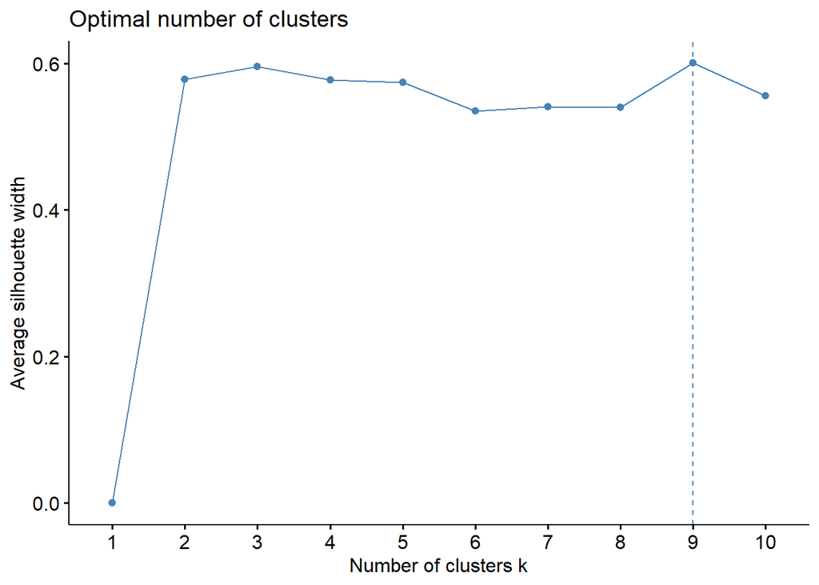

```r
## Determining Optimal Number of Clusters and Creating Clusters
set.seed(13)

fviz_nbclust(cluster1, FUNcluster = kmeans)
```

```r
# 9 clusters is determined to be the optimal amount
k <- kmeans(cluster1, 9, nstart = 50)
```

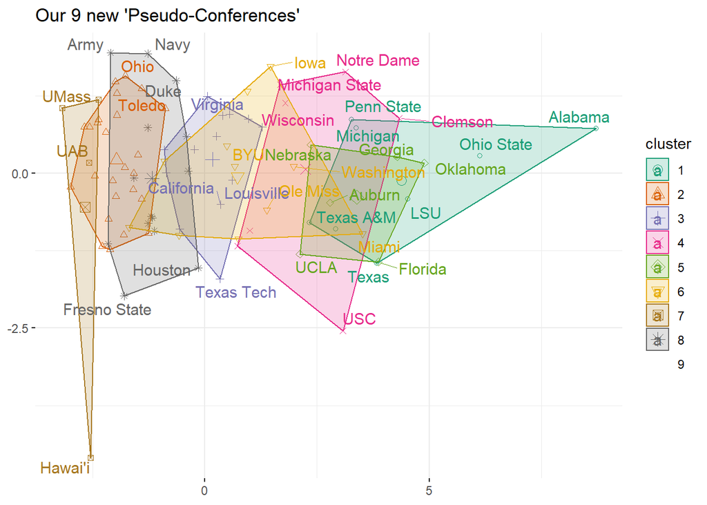

```r
## Visualizing Clusters and Attaching Clusters to our data used in our regression analysis
fviz_cluster(k, data = cluster1, ggtheme = theme_minimal(), repel = TRUE,
             palette = "Dark2", xlab = FALSE, ylab = FALSE, main = "Our 9 new 'Pseudo-Conferences'")
```

```r
cbind(cluster1, cluster = k$cluster) %>%
    mutate(school = row.names(cluster1)) %>%
    as_tibble() %>%
    select(school, cluster) -> clusters
```

### Preparing Data for Regression Models

Now that we have established some sort of baseline level of expectations for each program, we prepare other data to get scores for each coach in the 3 aforementioned areas.

```r
## Home Game Info

gms21 <- cfbd_game_info(year = 2021)
gms19 <- cfbd_game_info(year = 2019)
gms18 <- cfbd_game_info(year = 2018)
gms17 <- cfbd_game_info(year = 2017)
gms16 <- cfbd_game_info(year = 2016)

games <- rbind(gms16, gms17, gms18, gms19, gms21)

# Gathering teams' average attendance
games %>%
    group_by(home_team) %>%
    summarise_at(vars(attendance), list(mean)) %>% drop_na(attendance) -> attendance
```

```r
# At this point, I'm not sure if I had already done this but this is me gathering data for the regression models
left_join(coachesDf, talent) %>%
    mutate(CoachName = paste(first_name, last_name)) %>%
    select(CoachName, hire_date, school, year, talent) %>%
    filter(year >= 2015) -> coach_talent
coach_talent %>%
    right_join(fpi, by = c("school" = "name", "year" = "year")) %>%
    left_join(teamInfo, by = c("school" = 'school')) %>%
    left_join(attendance, by = c("school" = "home_team")) %>%
    left_join(draftDF, by = c("year" = "year", "school" = "college_team")) %>%
    left_join(clusters) %>%
    mutate(clusters = as.factor(cluster),
           talent = if_else(is.na(talent), 0, talent)) -> fullCoachData
```

## Using Linear Regression to Create Scores

### Talent Maximization Score

The idea here is that we are trying to predict a team’s success (measured by FPI) with two variables, the NFL draft talent on a roster as well as the coach. the ‘totalGrade’ variable will be a big contributor, but good coaches will turn this talent into a higher FPI more often.

```r
talentFpiModel <- lm(fpi ~ CoachName + totalGrade, data = fullCoachData)

talentFpiModel$coefficients %>% as.data.frame() %>% head(205) %>% slice(-1) -> talFpi_coeff

row.names(talFpi_coeff) -> coaches

talFpiCoeff <- tibble(coaches, talFpi_coeff$.)

talFpiCoeff %>%
    mutate(coaches = substring(coaches, 10)) %>%
    right_join(fullCoachData, by = c("coaches" = "CoachName")) %>%
    rename(talFpiCoeff = `talFpi_coeff$.`) %>%
    arrange(-talFpiCoeff) %>%
    select(coaches, talFpiCoeff, school, year) %>%
    group_by(school) %>%
    #filter(year == 2022) %>%
    slice(which.max(year)) %>%
    drop_na(coaches) -> tfd2

# Rescaling these coefficients to create a score from 0 for the worst coach at mazimizing NFL talent, to the best coach
tfd2 %>%
    cbind(talFpiScore = scales::rescale(tfd2$talFpiCoeff, by = c(0,100))*100) %>%
    select(-talFpiCoeff) -> talFpiData
```

### Player Development Score

Similar methodology as the score above but we want to see which coaches provide the biggest boost to the talent recruited to their schools.

```r
coachModel <- lm(fpi ~ CoachName + talent, data = fullCoachData)

coachModel$coefficients %>% as.data.frame() %>% head(205) %>% slice(-1) -> coach_coeff

row.names(coach_coeff) -> coaches

coachCoeff <- tibble(coaches, coach_coeff$.)

coachCoeff %>%
    mutate(coaches = substring(coaches, 10)) %>%
    right_join(fullCoachData, by = c("coaches" = "CoachName")) %>%
    rename(talentMaxCoeff = `coach_coeff$.`) %>%
    arrange(-talentMaxCoeff) %>%
    select(coaches, talentMaxCoeff, school, year, talent) %>%
    group_by(coaches) -> cd

cd %>%
    summarise_at(vars(talentMaxCoeff), list(mean)) -> cd1

cd %>%
    left_join(cd1) %>%
    group_by(school) %>%
    slice(which.max(year)) %>%
    drop_na(coaches) -> cd2
cd2 %>%
    cbind(talentMaxScore = scales::rescale(cd2$talentMaxCoeff, by = c(0,100))*100) %>%
    right_join(cfbd_team_info()) %>%
    unique() -> fullCoachData2
```

### Recruiting Score

When we consider who the best recruiters are, we must consider what type of program these schools are, thus we use the cluster variable. We also use attendance as a proxy for fan engagement, which may vary in clusters outside the most elite one or two.

```r
rec17 <- cfbd_recruiting_team(year = 2017)
rec18 <- cfbd_recruiting_team(year = 2018)
rec19 <- cfbd_recruiting_team(year = 2019)
rec20 <- cfbd_recruiting_team(year = 2020)
rec21 <- cfbd_recruiting_team(year = 2021)

recruiting_data <- rbind(rec17,rec18,rec19,rec20,rec21)


fullCoachData %>%
    left_join(recruiting_data, by = c("year" = "year", "school" = "team")) %>%
    drop_na(capacity, attendance) %>%
    filter(capacity > 0 & attendance > 0) %>%
    mutate(attendanceRate = attendance/capacity) -> fullCoachData3

# Predicting 247 composite recruiting class rankings
talentModel <- lm(points ~ CoachName + attendance + cluster, data = fullCoachData3)

talentModel$coefficients %>% as.data.frame() -> talent_coeff

row.names(talent_coeff) -> talent

talentCoeff <- tibble(talent, talent_coeff$.)

talentCoeff %>%
    rename(recruitingCoeff = `talent_coeff$.`) %>%
    filter(grepl("CoachName", talent)) %>%
    mutate(coaches = substring(talent, 10)) %>%
    select(-talent) %>%
    right_join(fullCoachData, by = c("coaches" = "CoachName")) %>%
    arrange(-recruitingCoeff) %>%
    select(coaches, recruitingCoeff, school, year, talent) %>%
    group_by(coaches) -> td

td %>%
    summarise_at(vars(recruitingCoeff), list(mean)) -> td1

td %>%
    left_join(td1) %>%
    group_by(school) %>%
    slice(which.max(year)) %>%
    drop_na(coaches, recruitingCoeff) -> td2
td2 %>%
    cbind(recruitingScore = scales::rescale(td2$recruitingCoeff, by = c(0,100))*100) -> talentData2
```

## Compiling Total Scores

```r
## What coaches are still coaching in 2022, who switched jobs?
cfbd_coaches(year = 2022) -> coaches22

coaches22 %>%
    mutate(name = paste(first_name, last_name)) %>%
    left_join(teamInfo) %>%
    select(School = school, Conference = conference, name) -> c22
fullCoachData3 %>%
    left_join(c22, by = c("coaches" = "name")) %>%
    left_join(talFpiData1) %>%
    left_join(talentData2) %>%
    ungroup() %>%
    select(-c(school, conference)) %>%
    drop_na(School) %>%
    select(Coach = coaches, School, talentMaxScore, talentToWinsScore = talFpiScore, recruitingScore) %>%
    mutate(TotalScore = talentMaxScore*0.45 + talentToWinsScore*0.3 + recruitingScore*0.25) %>%
    unique() %>%
    arrange(-TotalScore) -> coachesFinal
```

## Final Rankings

With that we get our final rankings… Here are my top 50 coaches for the 2022 College Football Season

```r
coachesFinal %>% head(50) %>% select(-c(talentToWinsScore, talentMaxScore, recruitingScore)) %>%
    print.data.frame()
```

```
##                Coach         School TotalScore
## 1         Nick Saban        Alabama  100.00000
## 2       Dabo Swinney        Clemson   91.12170
## 3        Kirby Smart        Georgia   89.97614
## 4           Ryan Day     Ohio State   89.44236
## 5      Lincoln Riley            USC   79.86724
## 6        Brian Kelly            LSU   79.24809
## 7    Mario Cristobal          Miami   74.79438
## 8       Jimbo Fisher      Texas A&M   70.93893
## 9     James Franklin     Penn State   70.79061
## 10      Jim Harbaugh       Michigan   69.57207
## 11        Mike Gundy Oklahoma State   69.00502
## 12       Paul Chryst      Wisconsin   67.63916
## 13  Kyle Whittingham           Utah   67.01431
## 14     Matt Campbell     Iowa State   66.74532
```

[output cut: 36 more lines]

### Validating Results

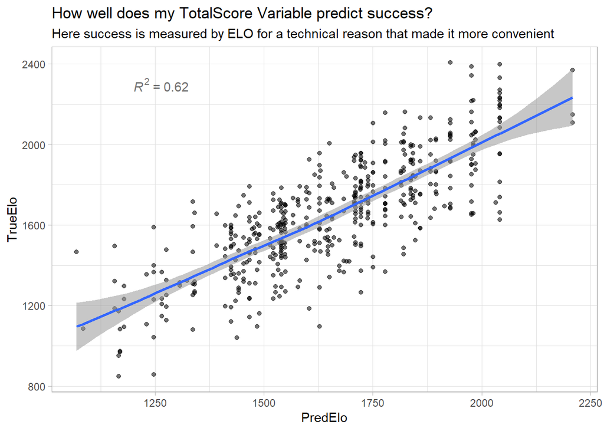

```r
cfbd_ratings_elo() %>%
    left_join(coachesDf, by = c("team" = "school", "year")) %>%
    mutate(coach = paste(first_name, last_name)) %>%
    select(year, team, elo, coach) %>%
    left_join(coachesFinal, by = c("coach" = "Coach")) %>%
    left_join(clusters, by = c("team" = "school")) %>%
    drop_na(TotalScore, cluster) %>%
    mutate(cluster = as.factor(cluster)) -> validate

# Adjusting for program expectations w/cluster variable
validateModel <- lm(elo ~ coach + cluster, data = validate)

data.frame(validate$elo, validateModel$fitted.values) %>%
    rename(TrueElo = 1, PredElo = 2) %>%
    ggplot(aes(x = PredElo, y = TrueElo, alpha = 0.8)) +
    geom_point() +
    geom_smooth() +
    stat_regline_equation(label.y = 2300, label.x = 1200, aes(label = ..rr.label..)) +
    theme_light() +
    theme(legend.position="none") +
    ggtitle("How well does my TotalScore Variable predict success?",
            subtitle = "Here success is measured by ELO for a technical reason that made it more convenient")
```

## Next Steps

- One area this model could be stronger is comparing coaches at group of 5 schools relative to their peers at Power 5 schools, when comparing coaches at smaller schools the cream rises to the top but when compared to the entire FBS pool of coaches some coaches aren’t getting their due (looking at Luke Fickell)
- I’m working on weighting more recent results more strongly. I think Mack Brown is earning more legacy points than he is for his current body of work
- I’m working on creating an objective way of identifying “exceptions to the rule” within clusters. Schools like Northwestern and Stanford have different recruiting strategies that their coaches shouldn’t shoulder the blame for. The service academies don’t have really any draft talent given their commitments, so how else can measure their roster’s talent apart from the team’s overall sucess.

```r
tbl <- reactable(
    rankings,
    pagination = FALSE,
    defaultSorted = "TotalScore",
    defaultSortOrder = "desc",
    defaultColGroup = colGroup(headerVAlign = "bottom"),
    columnGroups = list(
        colGroup(name = "Team", columns = team_cols),
        colGroup(name = "Scores", columns = rating_cols)
    ),
    defaultColDef = colDef(
        vAlign = "center",
        headerVAlign = "bottom",
        class = "cell",
        headerClass = "header"
    ),
    columns = list(
        School = colDef(defaultSortOrder = "asc", align = "center", maxWidth = 75,
               class = "cell group", headerStyle = list(fontWeight = 700)),
        Coach = colDef(defaultSortOrder = "asc", align = "center", maxWidth = 75,
               class = "cell group", headerStyle = list(fontWeight = 700)),
        cluster = colDef(defaultSortOrder = "asc", align = "center", maxWidth = 75,
               class = "cell group", headerStyle = list(fontWeight = 700)),
        # talentMaxScore = rating_column(name = "Player Development Score", class = "border-left"),
        # talentToWinsScore = rating_column(name = "Talent Maximization Score", maxWidth = 200)
        # recruitingScore = rating_column(name = "Recruiting Score"),
        totalScore = colDef(style = function(value) {
            normalized <- (value - min(rankings$TotalScore)) / (max(rankings$TotalScore) - min(rankings$TotalScore))
            color <- rating_colors(value)
            list(background = color)
        })
    ),
    ## Emphasize Cluster Groups
    rowClass = JS("
    function(rowInfo, state) {
      const firstSorted = state.sorted[0]
      if (firstSorted && firstSorted.id === 'group') {
        const nextRow = state.pageRows[rowInfo.viewIndex + 1]
        if (nextRow && rowInfo.values['cluster'] !== nextRow.cluster) {
          return 'cluster-last'
        }
      }
    }"
  ),
  showSortIcon = FALSE,
  borderless = TRUE,
  class = "cluster-table"
)
```

```r
tbl
```

| School | Coach | cluster | Conference | recruitingScore | talentMaxScore | talentToWinsScore | TotalScore |
| --- | --- | --- | --- | --- | --- | --- | --- |
| Alabama | Nick Saban | 1 | SEC | 100 | 100 | 100 | 100 |
| Clemson | Dabo Swinney | 4 | ACC | 88.0856245248659 | 95.1928111994647 | 87.5451099422996 | 91.1217041536654 |
| Georgia | Kirby Smart | 5 | SEC | 88.5793189588291 | 92.156293670167 | 87.8699316482599 | 89.9761413857604 |
| Ohio State | Ryan Day | 1 | Big Ten | 66.1635710698296 | 97.6924199470752 | 96.4662648443026 | 89.442361196932 |
| USC | Lincoln Riley | 4 | Pac-12 | 67.7129725809103 | 86.6535476023613 | 79.8163348520235 | 79.8672400218972 |
| LSU | Brian Kelly | 1 | SEC | 73.8044535230047 | 83.0804247348649 | 78.0359561968917 | 79.2480913705079 |
| Miami | Mario Cristobal | 6 | ACC | 84.3839369877069 | 74.1462631637363 | 67.7752561762996 | 74.7943795234979 |
| Texas A&M | Jimbo Fisher | 1 | SEC | 63.2351549926668 | 75.9289024723887 | 69.8737898648689 | 70.9389318202023 |
| Penn State | James Franklin | 1 | Big Ten | 48.6272747879395 | 81.1549346416441 | 73.7135631001163 | 70.7906082157596 |
| Michigan | Jim Harbaugh | 1 | Big Ten | 48.8521308627562 | 76.4316971218605 | 76.5492523082631 | 69.5720721130052 |

[output cut: 77 more lines]